# Practical Machine Learning - Coursera Project

Samuel Tandoh

8/9/2021

## Background

Using devices such as Jawbone Up, Nike FuelBand, and Fitbit it is now possible to collect a large amount of data about personal activity relatively inexpensively. These type of devices are part of the quantified self movement – a group of enthusiasts who take measurements about themselves regularly to improve their health, to find patterns in their behavior, or because they are tech geeks. One thing that people regularly do is quantify how much of a particular activity they do, but they rarely quantify how well they do it. In this project, your goal will be to use data from accelerometers on the belt, forearm, arm, and dumbell of 6 participants. They were asked to perform barbell lifts correctly and incorrectly in 5 different ways. More information is available from the website here: http://web.archive.org/web/20161224072740/http:/groupware.les.inf.puc-rio.br/har (see the section on the Weight Lifting Exercise Dataset).

## Data

The training data for this project are available here: https://d396qusza40orc.cloudfront.net/predmachlearn/pml-training.csv

The test data are available here: https://d396qusza40orc.cloudfront.net/predmachlearn/pml-testing.csv

The data for this project come from this source: http://web.archive.org/web/20161224072740/http:/groupware.les.inf.puc-rio.br/har. If you use the document you create for this class for any purpose please cite them as they have been very generous in allowing their data to be used for this kind of assignment.

## Loading the Libraries

```r
library(caret)
library(rpart)
```

```r
library(rpart.plot)
library(randomForest)
library(corrplot)
```

## Data Preparation

### Loading the Data

After downloading the data from the data source, we can read the two csv files into two data frames.

```
## [1] 19622   160
```

```
## [1]  20 160
```

### Dealing with Missing data

- We filter out all records that contain more than 95% of the observations being NA.

[output not shown]

- Columns 1 to 7 which are irrelevant to the analysis were removed from the data subset.

### Cross-Validation

In this section cross-validation will be performed by splitting the training data in training (75%) and testing (25%) data.

```r
set.seed(22603)
inTrain <- createDataPartition(clean_pml_training$classe, p=0.75)[[1]]
training_data <- clean_pml_training[inTrain,]
testing_data <- clean_pml_training[-inTrain,]
```

```r
allNames <- names(clean_pml_training)
clean_pml_testing <- pml_testing[,allNames[1:52]]
```

## Data Modeling

### 1. Random Forest

We fit a predictive model for activity recognition using Random Forest algorithm because it automatically selects important variables and is robust to correlated covariates & outliers in general. We will use 5-fold cross validation when applying the algorithm.

```r
rf_Ctrl <- trainControl(method="cv", 5)
rf_model <- train(classe ~ ., data=training_data, method="rf", trControl=rf_Ctrl, ntree=250)
rf_model
```

```
## Random Forest
##
## 14718 samples
##    52 predictor
##     5 classes: 'A', 'B', 'C', 'D', 'E'
##
## No pre-processing
## Resampling: Cross-Validated (5 fold)
## Summary of sample sizes: 11775, 11774, 11775, 11774, 11774
## Resampling results across tuning parameters:
##
##   mtry  Accuracy   Kappa
##    2    0.9910315  0.9886542
##   27    0.9911673  0.9888269
##   52    0.9836932  0.9793696
##
## Accuracy was used to select the optimal model using the largest value.
## The final value used for the model was mtry = 27.
```

The performance of the model on the validation data set is estimated as follows

```r
predict_rf <- predict(rf_model, testing_data)
confusionMatrix((as.factor(testing_data$classe)), predict_rf)
```

```
## Confusion Matrix and Statistics
##
##           Reference
## Prediction    A    B    C    D    E
##          A 1391    3    0    0    1
##          B    7  939    3    0    0
##          C    0    6  845    4    0
##          D    0    0   11  792    1
##          E    0    0    2    1  898
##
## Overall Statistics
##
##                Accuracy : 0.992
##                  95% CI : (0.9891, 0.9943)
##     No Information Rate : 0.2851
##     P-Value [Acc > NIR] : < 2.2e-16
##
##                   Kappa : 0.9899
##
##  Mcnemar's Test P-Value : NA
##
## Statistics by Class:
##
##                      Class: A Class: B Class: C Class: D Class: E
## Sensitivity            0.9950   0.9905   0.9814   0.9937   0.9978
## Specificity            0.9989   0.9975   0.9975   0.9971   0.9993
## Pos Pred Value         0.9971   0.9895   0.9883   0.9851   0.9967
## Neg Pred Value         0.9980   0.9977   0.9960   0.9988   0.9995
## Prevalence             0.2851   0.1933   0.1756   0.1625   0.1835
## Detection Rate         0.2836   0.1915   0.1723   0.1615   0.1831
## Detection Prevalence   0.2845   0.1935   0.1743   0.1639   0.1837
## Balanced Accuracy      0.9969   0.9940   0.9895   0.9954   0.9985
```

```r
accuracy <- postResample(predict_rf, (as.factor(testing_data$classe)))
accuracy
```

```
##  Accuracy     Kappa
## 0.9920473 0.9899400
```

Out of Sample Error

```r
ooserror <- 1 - as.numeric((confusionMatrix((as.factor(testing_data$classe)), predict_rf))$overall[1])
ooserror
```

```
## [1] 0.007952692
```

### 2. Decision Tree

```r
dt_model <- train(classe ~., method='rpart', data=training_data)
```

Prediction

```r
dt_predict <- predict(dt_model, testing_data)
confusionMatrix((as.factor(testing_data$classe)), dt_predict)
```

```
## Confusion Matrix and Statistics
##
##           Reference
## Prediction    A    B    C    D    E
##          A 1283   21   87    0    4
##          B  398  331  220    0    0
##          C  394   29  432    0    0
##          D  361  124  319    0    0
##          E  130  128  244    0  399
##
## Overall Statistics
##
##                Accuracy : 0.4986
##                  95% CI : (0.4845, 0.5127)
##     No Information Rate : 0.5232
##     P-Value [Acc > NIR] : 0.9997
##
##                   Kappa : 0.3444
##
##  Mcnemar's Test P-Value : NA
##
## Statistics by Class:
##
##                      Class: A Class: B Class: C Class: D Class: E
## Sensitivity            0.5000   0.5229  0.33180       NA  0.99007
## Specificity            0.9521   0.8553  0.88257   0.8361  0.88847
## Pos Pred Value         0.9197   0.3488  0.50526       NA  0.44284
## Neg Pred Value         0.6344   0.9236  0.78513       NA  0.99900
## Prevalence             0.5232   0.1291  0.26550   0.0000  0.08218
## Detection Rate         0.2616   0.0675  0.08809   0.0000  0.08136
## Detection Prevalence   0.2845   0.1935  0.17435   0.1639  0.18373
## Balanced Accuracy      0.7260   0.6891  0.60718       NA  0.93927
```

## Prediction

Now we use the Random Forest algorithm to predict the test data set

```r
predict(rf_model, clean_pml_testing)
```

```
##  [1] B A B A A E D B A A B C B A E E A B B B
## Levels: A B C D E
```

## Appendix: Plots

### Figure 1. Correlation Matrix Visualization

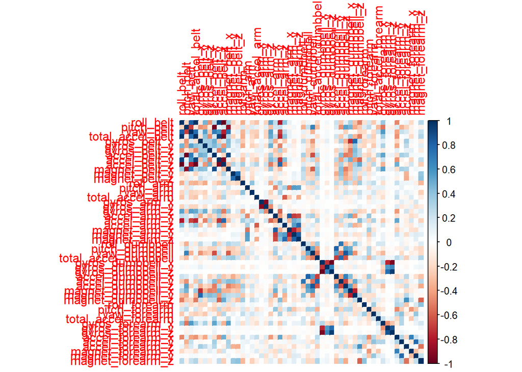

```r
corrPlot <- cor(training_data[, -length(names(training_data))])
corrplot(corrPlot, method="color")
```

### Figure 2. Decision Tree Visualization

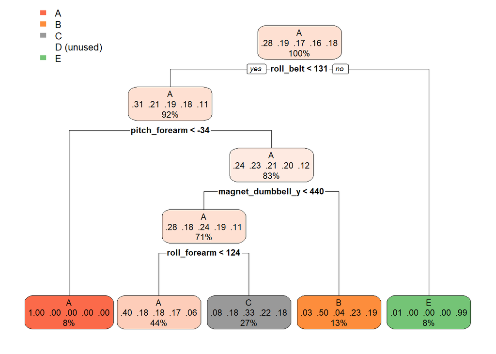

```r
rpart.plot(dt_model$finalModel)
```